# Notebook

### 11.3.1. Проверка на двух тканях: переменная глубина и конечное лёгкое

**Допущение автора для этого сравнения:** существуют только два значения удельного сопротивления. Лёгочная маска получает $\rho_2$, всё остальное внутри тела — $\rho_1$, включая кости, сердце и ткани ниже диафрагмы. Следовательно, «три слоя» здесь означают **мягкие ткани → лёгкое → мягкие ткани**, причём $\rho_3=\rho_1$. Это отдельная двухтканная постановка; четырёхтканный FEM выше сохранён как исходный расчёт.

**Входы и статус:** используются та же КТ на вдохе, те же девять размеров, общий центр, ориентация и CEM-площадки примера 11.3. Два сопротивления перенесены из исходной четырёхтканной подгонки и фиксированы. Новая подгонка по эксперименту не выполнялась. Все представленные ниже числа — результаты математических моделей, не независимая валидация анатомии, параметров или измерений.

В текущем сечении при $s=-70\ldots70$ мм первая глубина до лёгкого меняется примерно от 54 до 20 мм. Первый лёгочный интервал меняется примерно от 112 до 11 мм на концах сборки; в центре он составляет около 116 мм. Луч пересекает лёгочную маску четыре или шесть раз: одного конечного лёгочного интервала недостаточно, чтобы описать весь луч. Наличие пересечений установлено по STL; не все выходы из маски можно назвать диафрагмой.

**Что именно рассчитывается.** Плоская модель с постоянными толщинами решается через преобразование Ханкеля. Если $d_j$ — толщина слоя, $\lambda$ — пространственная частота, то спектральная величина $T_j$, имеющая единицы удельного сопротивления, получается снизу вверх:

$$ T_N=\rho_N,\qquad T_j(\lambda)=\rho_j\, \frac{T_{j+1}(\lambda)+\rho_j\tanh(\lambda d_j)} {\rho_j+T_{j+1}(\lambda)\tanh(\lambda d_j)}. $$

Для трёх слоёв $d_1=h$, $d_2=t_{lung}$, $\rho_3=\rho_1$. Поверхностное ядро точечного источника, после выделения однородной особенности, равно

$$ G(r)=\frac1{2\pi}\left[\frac{\rho_1}{r} +\int_0^\infty [T_1(\lambda)-\rho_1]J_0(\lambda r)\,d\lambda\right]. $$

Четырёхэлектродный импеданс собирается как $Z=G_{AM}-G_{BM}-G_{AN}+G_{BN}$. Длины внутри интеграла заданы в метрах. При $t_{lung}=0$ получается однородное полупространство, при $t_{lung}\to\infty$ — обычная двухслойная формула. Эти пределы проверены тестами. Такая рекурсия для горизонтальных слоёв используется и в [первичной реализации SimPEG](https://github.com/simpeg/simpeg/blob/main/simpeg/electromagnetics/static/resistivity/simulation_1d.py).

Сопоставлены следующие варианты:

- постоянное $h$: ближайшее расстояние до поверхности и отдельно глубина центрального луча;
- исходный 11.3: среднее $h$ отдельно для каждой пары электродов;
- усреднение самого ядра $G(r,h(s))$ вместо предварительного усреднения $h$;
- конечный первый лёгочный интервал: постоянный в центре или усреднённый по паре;
- все чередующиеся интервалы вдоль луча: центральный плоский стек и усреднение локальных плоских ядер по реальному сечению;
- полный двухтканный FEM с замкнутой лёгочной маской;
- FEM на той же сетке с теми же контактами, но с продолжением лёгкого после первого входа вдоль направления `inward` сечения, до границы тела.

**Физическая граница приближений:** плоские стеки решают соответствующую плоскую задачу. Подстановка средних толщин и усреднение ядер — эвристики. Они не обеспечивают условий непрерывности потенциала и нормального тока на исходных кривых границах. Простое выпрямление кожи также не является эквивалентной заменой геометрии: при точной замене координат $x=F(\xi)$, $J=\partial x/\partial\xi$, в уравнении появляется $\widetilde\sigma=|\det J|J^{-1}\sigma J^{-T}$. В FEM исходная трёхмерная форма учитывается непосредственно; маска назначается по центрам тетраэдров. Сходимость по сгущению этой сетки пока не проверена.

Вторая FEM-геометрия — контролируемое изменение **всех дальних выходов** вдоль одного направления, а не изолированное перемещение купола диафрагмы. Только разность двух FEM сравнивает эту замену при одинаковых конечных контактах, теле и численном методе. Аналитические формулы используют номинальные точечные электроды на плоскости; их невязку с CEM нельзя целиком приписывать кривизне лёгкого.

Фиксированы: **ρ₁=5.55217 Ом·м**, **ρ₂=30.70695 Ом·м**. Последний столбец описывает невязку с измерением; сопротивления под эти варианты не подгонялись.

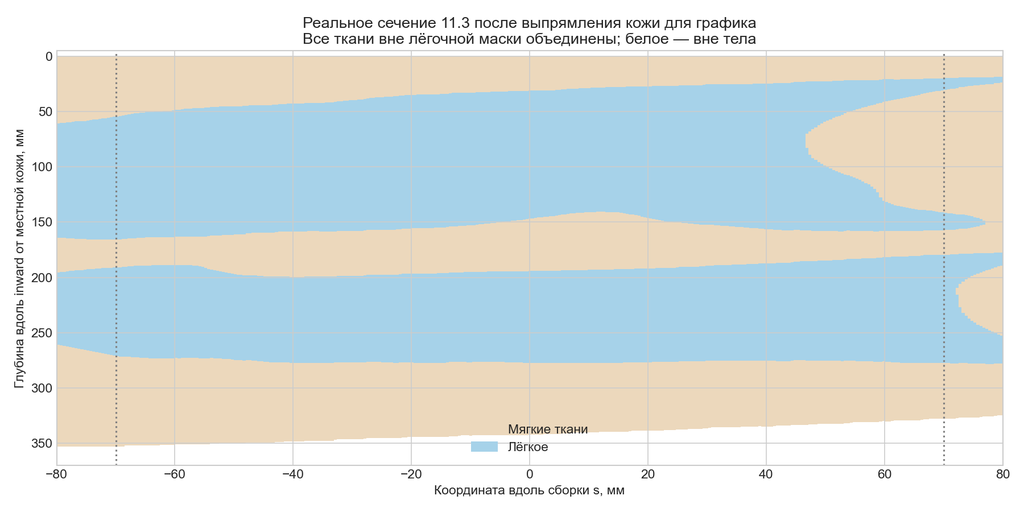

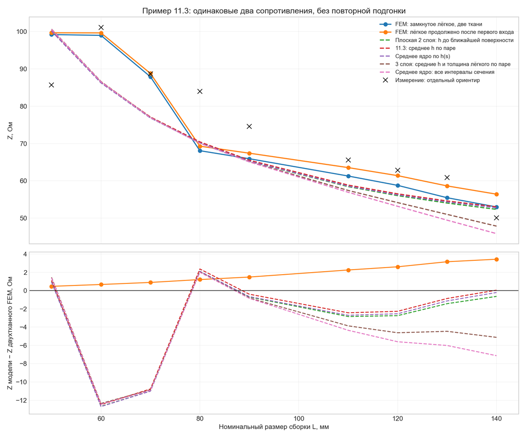

|  | Вариант | RMS относительно двухтканного FEM, Ом | Макс. расхождение с FEM, Ом | RMS относительно измерения, Ом |
| --- | --- | --- | --- | --- |
| 0 | Плоская 2 слоя: h до ближайшей поверхности | 5.8248 | 12.6673 | 10.5066 |
| 1 | 11.3: среднее h по паре | 5.6834 | 12.4845 | 10.3171 |
| 2 | Среднее ядро по h(s) | 5.8051 | 12.6985 | 10.4634 |
| 3 | Плоская 2 слоя: h по центральному лучу | 6.0238 | 12.9491 | 10.7430 |
| 4 | Плоская 3 слоя: первый интервал в центре | 6.1928 | 13.0820 | 10.9466 |
| 5 | 3 слоя: средние h и толщина лёгкого по паре | 6.3247 | 12.3538 | 11.0205 |
| 6 | Плоская: все интервалы центрального луча | 6.1524 | 13.0519 | 10.8992 |
| 7 | Среднее ядро: все интервалы сечения | 6.8153 | 12.4433 | 11.3975 |
| 8 | FEM: замкнутое лёгкое, две ткани | 0.0000 | 0.0000 | 8.0663 |
| 9 | FEM: лёгкое продолжено после первого входа | 2.0737 | 3.4317 | 7.5591 |

|  | L_mm | Z_experiment_ohm | Z_closed_lung_CEM_ohm | Z_extended_lung_CEM_ohm | adapted_mean_h | adapted_finite_interval | adapted_all_intervals |
| --- | --- | --- | --- | --- | --- | --- | --- |
| 0 | 50.0 | 85.689 | 99.1693 | 99.6350 | 100.2793 | 100.6186 | 100.5539 |
| 1 | 60.0 | 101.102 | 98.9473 | 99.6134 | 86.4629 | 86.5935 | 86.5040 |
| 2 | 70.0 | 88.678 | 87.8721 | 88.7637 | 77.0993 | 77.0056 | 76.9489 |
| 3 | 80.0 | 83.943 | 68.0830 | 69.2888 | 70.4469 | 70.1350 | 70.0873 |
| 4 | 90.0 | 74.580 | 65.9362 | 67.4167 | 65.5384 | 65.1208 | 65.0865 |
| 5 | 110.0 | 65.581 | 61.3060 | 63.5601 | 58.8748 | 57.4437 | 56.9577 |
| 6 | 120.0 | 62.821 | 58.8039 | 61.4079 | 56.5351 | 54.1873 | 53.2014 |
| 7 | 130.0 | 60.923 | 55.4996 | 58.6555 | 54.6309 | 51.0405 | 49.4900 |
| 8 | 140.0 | 50.103 | 53.0165 | 56.4482 | 53.0627 | 47.8954 | 45.8880 |

**Результат:** продолжение лёгкого изменяет FEM на **0.466–3.432 Ом**. Для этого примера добавление конечного слоя в усреднённую формулу не уменьшило расхождение с FEM. Более подробное описание сечения само по себе не делает усреднение решением трёхмерной задачи.

Контроль: максимальная ошибка взаимности **1.28e-13 Ом**; изменение усреднения всех интервалов при шаге сечения 2→1 мм — **0.0230 Ом**. Эта проверка квадратуры не заменяет сходимость FEM по сетке.